# Der Effekt des BIP-Wachstums auf die Nettozuwanderung in die Schweiz

Autor

Vincent Pickert - 2020-061-610

Veröffentlichungsdatum

14. Juni 2026

# Forschungsfrage und Hypothesen

Diese Arbeit untersucht den Effekt des BIP-Wachstums auf die Nettozuwanderung in die Schweiz, kontrolliert für die Arbeitslosenquote. Es wird erwartet, dass die Nettozuwanderung stark durch das BIP-Wachstum beeinflusst wird, da dies ein direkter Indikator für die Wirtschaftslage ist und somit die Einwanderung mitbestimmt.

Die Arbeitslosenquote wird als Kontrollvariable einbezogen, da sie als Arbeitsmarktindikator ebenfalls einen eigenständigen Einfluss auf Migrationsentscheide ausübt. Durch den langen Beobachtungszeitraum wird die Analyse weniger durch einzelne Ereignisse wie die Finanzkrise 2008 oder die COVID-19-Pandemie 2020 verzerrt.

Die zwei Regressionsmodelle lauten:

$$\text{Nettozuwanderung}_i = \beta_0 + \beta_1 \times \text{BIP-Wachstum}_i + \varepsilon_i$$

$$\text{Nettozuwanderung}_i = \beta_0 + \beta_1 \times \text{BIP-Wachstum}_i + \beta_2 \times \text{Arbeitslosenquote}_i + \varepsilon_i$$

Dabei repräsentiert $\beta_0$ die Konstante (Nettozuwanderung, wenn alle Variablen auf null gesetzt werden), $\beta_1$ den Effekt des BIP-Wachstums, $\beta_2$ den Effekt der Arbeitslosenquote und $\varepsilon_i$ den Fehlerterm, der alle nicht erfassten Abweichungen enthält.

# Daten

## Datenquellen

Die Schweizer Einwanderungsdaten (abhängige Variable) stammen vom Bundesamt für Statistik (BFS, 2024) und wurden als CSV-Dateien manuell heruntergeladen. Sie enthalten Angaben zu Herkunftsland, Jahr und Nettozuwanderung für den Zeitraum 1991-2024. Der Datensatz umfasst 15 europäische Länder. Die Beschränkung auf 15 Länder geht auf einen bestehenden Datensatz meiner Masterarbeit zurück und könnte die Repräsentativität der Ergebnisse begrenzen. Die folgende Tabelle zeigt alle enthaltenen Herkunftsländer:

**Code anzeigen**

```r
knitr::kable(
  data.frame(Herkunftsland = karten_laender_liste),
  align = "c"
) |>
  kableExtra::kable_styling(full_width = FALSE, position = "center")
```

| Herkunftsland |
| --- |
| Bosnien und Herzegowina |
| Deutschland |
| Frankreich |
| Großbritannien |
| Italien |
| Kosovo |
| Kroatien |
| Montenegro |
| Niederlande |
| Nordmazedonien |
| Österreich |
| Portugal |
| Serbien |
| Spanien |
| Türkei |

Die wirtschaftlichen Indikatoren (unabhängige und Kontrollvariable) stammen von den World Bank Indicators (World Bank, 2024a; 2024b):

- Jährliches BIP-Wachstum (Weltbank-ID: `NY.GDP.MKTP.KD.ZG`, [Link](https://data.worldbank.org/indicator/NY.GDP.MKTP.KD.ZG))
- Arbeitslosenquote (Weltbank-ID: `SL.UEM.TOTL.ZS`, [Link](https://data.worldbank.org/indicator/SL.UEM.TOTL.ZS))

# Deskriptive Statistik

Die Nettozuwanderung weist ein Minimum von -10’589 auf, was zeigt, dass es innerhalb der erfassten 15 Länder Jahre gab, in denen die Auswanderungen die Einwanderungen übertrafen. Der Median von 26’290 liegt unter dem Mittelwert von 27’759, was auf einzelne Jahre mit besonders hoher Zuwanderung hindeutet.

**Code anzeigen**

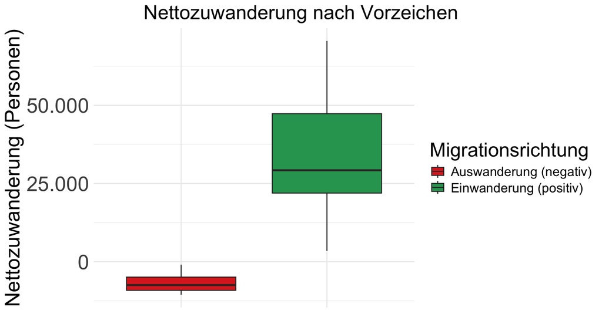

```r
boxplot_vorzeichen
```

**Code anzeigen**

```r
knitr::kable(
  zusammenfassung,
  digits      = 0,
  format.args = list(big.mark = "'"),
  caption     = "Deskriptive Kennzahlen nach Migrationsrichtung."
)
```

Deskriptive Kennzahlen nach Migrationsrichtung.

| migration_sign | Anzahl | Mittelwert | Median | SD | Min | Max | IQR |
| --- | --- | --- | --- | --- | --- | --- | --- |
| Auswanderung (negativ) | 4 | -6’629 | -7’478 | 4’167 | -10’589 | -970 | 4’220 |
| Einwanderung (positiv) | 30 | 32’344 | 29’210 | 17’609 | 3’446 | 70’558 | 25’377 |

Es gibt nur 4 Jahre mit negativer Nettozuwanderung gegenüber 30 Jahren mit positiver Nettozuwanderung.

## Zeitliche Entwicklung der Nettozuwanderung

**Code anzeigen**

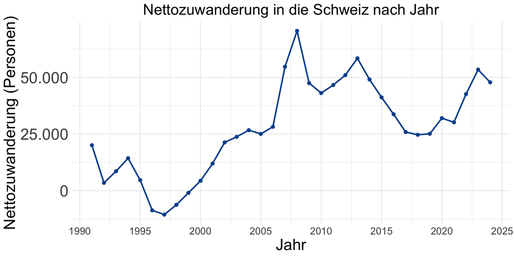

```r
kurven_diagramm
```

## Nettozuwanderung nach Herkunftsland

Die geographische Nähe spielt eine wichtige Rolle. Deutschland und Frankreich, die beiden wichtigsten Nachbarländer der Schweiz, verzeichnen mit Abstand die meisten Einwanderungen. Überraschenderweise weist Portugal eine höhere Einwanderung als Italien auf, was möglicherweise damit zusammenhängt, dass viele italienische Arbeitnehmer als Grenzgänger in der Schweiz arbeiten, aber ihren Wohnsitz in Italien behalten und daher nicht als Einwanderer gezählt werden.

Spanien zeigt sogar eine negative Nettozuwanderung, was bedeutet, dass mehr Menschen aus der Schweiz nach Spanien ausgewandert sind als umgekehrt.

**Code anzeigen**

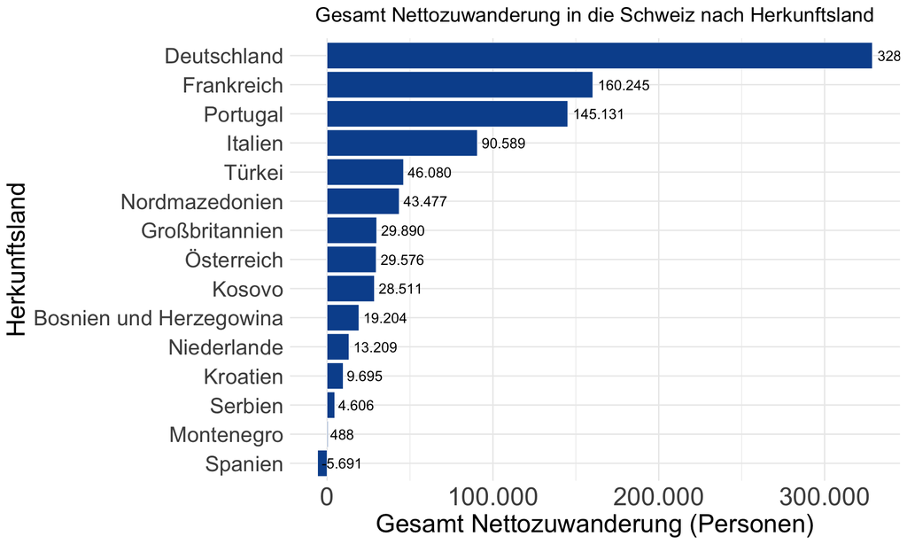

```r
horizontales_balkendiagramm
```

**Code anzeigen**

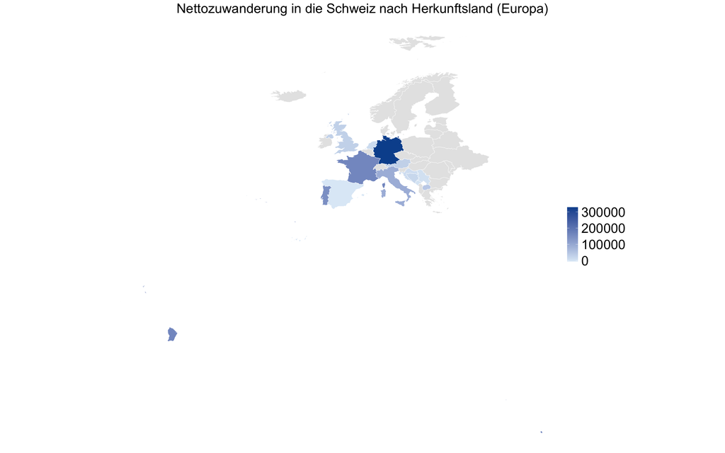

```r
schweiz_migrations_weltkarte
```

Abschliessend zeigt die folgende Tabelle die deskriptiven Kennzahlen der Analysevariablen, aufgeschlüsselt nach Migrationsrichtung:

**Code anzeigen**

```r
deskriptive_tabelle <- analysedaten_schweiz |>
  dplyr::mutate(
    migrationsrichtung = ifelse(
      netto_zuwanderung >= 0, "Einwanderung", "Auswanderung"
    )
  ) |>
  dplyr::select(
    migrationsrichtung, netto_zuwanderung, bip_wachstum, arbeitslosenquote
  ) |>
  gtsummary::tbl_summary(
    by        = migrationsrichtung,
    label     = list(
      netto_zuwanderung ~ "Nettozuwanderung",
      bip_wachstum      ~ "BIP-Wachstum (%)",
      arbeitslosenquote ~ "Arbeitslosenquote (%)"
    ),
    statistic = list(all_continuous() ~ "{mean} ({sd})"),
    digits    = all_continuous() ~ 2
  ) |>
  gtsummary::modify_header(label = "**Variable**") |>
  gtsummary::bold_labels() |>
  gtsummary::modify_footnote(
    all_stat_cols() ~ "Mittelwert (Standardabweichung)"
  ) |>
  gtsummary::add_p() |>
  gtsummary::modify_footnote(
    p.value ~ "Wilcoxon-Rangsummentest"
  ) |>
  gtsummary::as_gt() |>
  gt::tab_header(
    title    = "Deskriptive Statistik nach Migrationsrichtung",
    subtitle = "Mittelwert (Standardabweichung)"
  )

deskriptive_tabelle
```

Deskriptive Statistik nach Migrationsrichtung

Mittelwert (Standardabweichung)

| **Variable** | **Auswanderung** N = 4<sup>1</sup> | **Einwanderung** N = 30<sup>1</sup> | **p-value**<sup>2</sup> |
| --- | --- | --- | --- |
| Nettozuwanderung | -6,629.00 (4,166.53) | 32,344.03 (17,609.46) | <0.001 |
| BIP-Wachstum (%) | 1.86 (1.08) | 1.60 (1.79) | 0.8 |
| Arbeitslosenquote (%) | 3.61 (0.44) | 3.99 (0.87) | 0.3 |

<sup>1</sup> Mittelwert (Standardabweichung)  
<sup>2</sup> Wilcoxon-Rangsummentest

# Ergebnisse

## Regressionsanalyse

Es wurden zwei lineare Regressionsmodelle geschätzt, um die jährliche Nettozuwanderung zu erklären:

- **Modell 1:** Nettozuwanderung ~ BIP-Wachstum
- **Modell 2:** Nettozuwanderung ~ BIP-Wachstum + Arbeitslosenquote

**Code anzeigen**

```r
if (knitr::is_html_output()) {
  texreg::htmlreg(
    list(Modell_1 = modell_1_bip, Modell_2 = modell_2_bip_arbeitslosenquote),
    custom.model.names = c("Modell 1", "Modell 2"),
    custom.coef.names  = c("(Intercept)", "BIP-Wachstum", "Arbeitslosenquote"),
    custom.note        = "Abhängige Variable: Nettozuwanderung. Signifikanz: * p < 0.05, ** p < 0.01, *** p < 0.001",
    digits = 3, single.row = FALSE, include.f = TRUE, caption = ""
  )
} else {
  texreg::texreg(
    list(Modell_1 = modell_1_bip, Modell_2 = modell_2_bip_arbeitslosenquote),
    custom.model.names = c("Modell 1", "Modell 2"),
    custom.coef.names  = c("(Intercept)", "BIP-Wachstum", "Arbeitslosenquote"),
    custom.note        = "Abhängige Variable: Nettozuwanderung. Signifikanz: * p < 0.05, ** p < 0.01, *** p < 0.001",
    digits = 3, single.row = FALSE, include.f = TRUE,
    caption = "Regressionsergebnisse: Nettozuwanderung", label = "tab:regression"
  )
}
```

|  | Modell 1 | Modell 2 |
| --- | --- | --- |
| (Intercept) | 25865.412*** | -18119.406 |
|  | (5030.561) | (16129.429) |
| BIP-Wachstum | 1162.634 | -186.864 |
|  | (2143.425) | (1996.828) |
| Arbeitslosenquote |  | 11709.439** |
|  |  | (4119.349) |
| R<sup>2</sup> | 0.009 | 0.214 |
| Adj. R<sup>2</sup> | -0.022 | 0.163 |
| Num. obs. | 34 | 34 |
| F statistic | 0.294 | 4.220 |

Abhängige Variable: Nettozuwanderung. Signifikanz: * p < 0.05, ** p < 0.01, *** p < 0.001

Modell 1 zeigt, dass ein Anstieg des BIP-Wachstums um einen Prozentpunkt mit einer um durchschnittlich 1’163 Personen höheren Nettozuwanderung verbunden ist, dieser Effekt ist jedoch statistisch nicht signifikant (p > 0.05). Das Modell erklärt nur 0.9 % der Variation (R² = 0.009, adj. R² = -0.022, F = 0.3).

In Modell 2 ist unter Kontrolle der Arbeitslosenquote ein zusätzlicher Prozentpunkt BIP-Wachstum mit 187 Personen weniger Nettozuwanderung verbunden (nicht signifikant). Ein Anstieg der Arbeitslosenquote um einen Prozentpunkt ist mit einer um durchschnittlich 11’709 Personen höheren Nettozuwanderung verbunden (hoch signifikant, p < 0.01). Das Modell erklärt 21.4 % der Varianz (R² = 0.214, adj. R² = 0.163, F = 4.2). Die starke Zunahme des F-Werts von Modell 1 zu Modell 2 bestätigt, dass die Einbeziehung der Arbeitslosenquote das Modell signifikant verbessert, obwohl der unerklärte Anteil mit 78.6 % weiterhin hoch bleibt.

**Code anzeigen**

```r
knitr::kable(
  round(korrelationsmatrix, 3),
  caption = "Korrelationsmatrix der Modellvariablen."
) |>
  kableExtra::kable_styling(full_width = FALSE, position = "center")
```

Korrelationsmatrix der Modellvariablen.

|  | netto_zuwanderung | bip_wachstum | arbeitslosenquote |
| --- | --- | --- | --- |
| netto_zuwanderung | 1.000 | 0.095 | 0.462 |
| bip_wachstum | 0.095 | 1.000 | 0.238 |
| arbeitslosenquote | 0.462 | 0.238 | 1.000 |

# Diagnostik

## Autokorrelationsanalyse

**Code anzeigen**

```r
knitr::kable(
  head(autokorrelations_daten, 4),
  digits = 3,
  col.names = c("Lag", "Autokorrelation")
) |>
  kableExtra::kable_styling(full_width = FALSE, position = "center")
```

| Lag | Autokorrelation |
| --- | --- |
| 1 | 0.739 |
| 2 | 0.380 |
| 3 | 0.213 |
| 4 | 0.144 |

Die ersten vier Lags deuten auf eine starke zeitliche Abhängigkeit der Residuen hin. Insbesondere Lag 1 (r = 0.74) und Lag 2 (r = 0.38) überschreiten die 95%-Konfidenzgrenze von +/-0.336 (berechnet als 1.96 / sqrt(n) mit n = 34 Beobachtungen), was darauf hindeutet, dass diese Korrelationen nicht zufällig entstanden sind. Die Fehlerterme sind damit nicht unabhängig, was eine zentrale Annahme der OLS-Regression verletzt. Die Ergebnisse legen nahe, dass das Modell die zeitliche Struktur der Daten nicht vollständig erfasst, etwa weil ein langfristiger Trend fehlt oder die Nettozuwanderung eines Jahres von den Werten der Vorjahre beeinflusst wird.

# Schluss

Die Analyse zeigt, dass die Nettozuwanderung eine hohe Volatilität aufweist und von wenigen Jahren mit extrem hoher Einwanderung dominiert wird. Die geographische Nähe spielt eine entscheidende Rolle: Deutschland und Frankreich verzeichnen mit Abstand die meisten Einwanderungen. Spaniens negative Nettozuwanderung innerhalb des Datensatzes deutet auf Rückwanderungsmuster hin.

Die vorliegenden Ergebnisse sind durch mehrere methodische Einschränkungen begrenzt. Der Datensatz umfasst nur 15 Herkunftsländer, was die Repräsentativität stark einschränkt. Die im Datensatz ausgewiesenen Jahre mit negativer Nettozuwanderung sind ausschliesslich auf diese begrenzte Länderauswahl zurückzuführen: Gemäss BFS-Daten (BFS, 2024) hat die Schweiz in den untersuchten Jahren gesamthaft nie eine negative Nettozuwanderung verzeichnet. Zudem beschränkt sich das Modell auf drei Variablen. Die kontraintuitiven Ergebnisse, insbesondere der positive Effekt der Arbeitslosenquote, sind eine direkte Folge dieser Einschränkung. Die Einwanderung wird durch eine Vielzahl weiterer Faktoren beeinflusst, die im vorliegenden Modell nicht berücksichtigt werden (Massey et al., 1993). Die Ergebnisse sind daher ausschliesslich im Kontext dieser Arbeit zu interpretieren.

# Literaturverzeichnis

**Bundesamt für Statistik (BFS).** (2024). *Ständige ausländische Wohnbevölkerung nach Staatsangehörigkeit, 1991-2024*. Bundesamt für Statistik, Bern. https://www.bfs.admin.ch

**Massey, D. S., Arango, J., Hugo, G., Kouaouci, A., Pellegrino, A., & Taylor, J. E.** (1993). Theories of international migration: A review and appraisal. *Population and Development Review*, 19(3), 431-466.

**World Bank.** (2024a). *GDP growth (annual %) - Switzerland* [Datensatz]. World Bank Open Data. https://data.worldbank.org/indicator/NY.GDP.MKTP.KD.ZG

**World Bank.** (2024b). *Unemployment, total (% of total labor force) (modeled ILO estimate) - Switzerland* [Datensatz]. World Bank Open Data. https://data.worldbank.org/indicator/SL.UEM.TOTL.ZS